# iris

## O Danych

Zbiór danych zawiera informacje o trzech gatunkach irysów: Iris setosa, Iris versicolor, i Iris virginica.

Dane obejmują pomiary czterech cech: długość i szerokość działki kielicha oraz długość i szerokość płatka.

Każdy wiersz w zbiorze danych reprezentuje pojedynczy kwiat, a wartości pomiarów są podane w centymetrach.

Zbiór składa się z 150 próbek, po 50 dla każdego gatunku, i jest szeroko stosowany jako podstawowy zbiór danych do testowania algorytmów klasyfikacji oraz w nauce o danych i uczeniu maszynowym.

Kolumny:

- **długość kielicha (sepal length)** - Długość kielicha w cm
- **szerokość kielicha (sepal width)** - Szerokość kielicha w cm
- **długość płatka (petal length)** - Długość płatka w cm
- **szerokość płatka (petal width)** - Szerokość płatka w cm
- **klasa (class)** - Klasa irysa (setosa, versicolor, virginica)

### Opisy gatunków irysów:

#### Iris setosa – irys szczecinkowy

- Występuje w chłodnym klimacie północnym (m.in. w Ameryce Północnej i Azji).
- Ma niebieskofioletowe kwiaty z charakterystycznymi, wąskimi płatkami.
- Często rośnie na wilgotnych terenach i torfowiskach.

[figure not shown]

*w:ru:Денис Анисимов (talk | contribs), Public domain, via Wikimedia Commons*

#### Iris versicolor (irys różnobarwny)

- Pochodzi z Ameryki Północnej, preferuje wilgotne tereny przybrzeżne.
- Kwiaty mają odcienie niebieskiego, fioletowego i czasem białego z żółtymi akcentami.

[figure not shown]

*Autor Nieznany / Unknown author, Public domain, Wikimedia Commons*

#### Iris virginica – irys wirginijski

- Występuje we wschodnich USA na mokradłach i terenach podmokłych.
- Kwiaty są fioletowe, często ciemniejsze od Iris versicolor, z żółtymi i białymi wzorami.
- Rośnie w kępach, a jego łodyga jest wyższa niż u poprzednich dwóch gatunków

[figure not shown]

*Frank Mayfield, CC BY-SA 2.0 https://creativecommons.org/licenses/by-sa/2.0, via Wikimedia Commons*

## SPIS TREŚCI

1. Ogólna analiza danych
2. Analiza brakujacych wartości
3. Analiza pojedynczych zmiennnych
4. Transformacja danych
5. Analiza relacji
6. Analiza wartości odstających

**Wczytanie danych**

długość kielicha (sepal length)

szerokość kielicha (sepal width)

długość płatka (petal length)

szerokość płatka (petal width)

klasa (class)

[figure not shown]

### KROK 1 - ogólna analiza danych

**Sprawdzenie podstawowych informacji o danych:**

```
<class 'pandas.core.frame.DataFrame'>
RangeIndex: 150 entries, 0 to 149
Data columns (total 5 columns):
 #   Column                            Non-Null Count  Dtype
---  ------                            --------------  -----
 0   długość kielicha (sepal length)   150 non-null    float64
 1   szerokość kielicha (sepal width)  150 non-null    float64
 2   długość płatka (petal length)     150 non-null    float64
 3   szerokość płatka (petal width)    150 non-null    float64
 4   klasa (class)                     150 non-null    object
dtypes: float64(4), object(1)
memory usage: 6.0+ KB
```

```
(150, 5)
```

##### Uproszczenie nazw kolumn dla zwiększenia czytelności

długość kielicha

szerokość kielicha

długość płatka

szerokość płatka

klasa

[figure not shown]

```
3
```

długość kielicha

szerokość kielicha

długość płatka

szerokość płatka

klasa

[figure not shown]

count

mean

std

min

25%

50%

75%

max

[figure not shown]

count

klasa

[figure not shown]

**Rozkład wartości dla poszczególnych cech:**

##### 1. Długość kielicha:

Średnia: 5.84 cm,

Odchylenie standardowe: 0.83 cm

Wartości wahają się od 4.3 (min.) cm do 7.9 (max.) cm, co wskazuje na stosunkowo szeroki zakres.

##### 2. Szerokość kielicha:

Średnia: 3.05 cm

Odchylenie standardowe: 0.43 cm

Minimalna wartość 2.0 cm, maksymalna 4.4 cm – najszerszy kielich jest ponad dwukrotnie większy od najwęższego.

##### 3. Długość płatka:

Średnia: 3.76 cm

Odchylenie standardowe: 1.76 cm

Wartości wahają się od 1.0 cm (min.) do 6.9 cm (max.), co sugeruje duże różnice między gatunkami

##### 4. Szerokość płatka:

Średnia: 1.20 cm

Odchylenie standardowe: 0.76 cm

**Wstępna analiza opisowa pokazała nam ogólne rozkłady cech, ale nie powiedziała nic o różnicach między poszczególnymi gatunkami irysów. Warto przeprowadzić analizę statystyczną dla każdej klasy osobno. Podział na klasy pozwoli nam sprawdzić, które cechy najlepiej różnicują te kwiaty.**

klasa

Iris-setosa

Iris-versicolor

Iris-virginica

[figure not shown]

klasa

Iris-setosa

Iris-versicolor

Iris-virginica

[figure not shown]

klasa

Iris-setosa

Iris-versicolor

Iris-virginica

[figure not shown]

klasa

Iris-setosa

Iris-versicolor

Iris-virginica

[figure not shown]

### KROK 2 - analiza brakujących wartości

index

Ilość

[figure not shown]

Każda kolumna zawiera dokładnie 150 wartości, co oznacza, że nie ma brakujących danych. Każda z trzech klas (Iris-setosa, Iris-versicolor, Iris-virginica) ma po 50 próbek.

### KROK 3 - analiza pojedynczych zmiennych

##### HISTOGRAMY pokażą nam jak rozkładają się wartości poszczególnych cech.

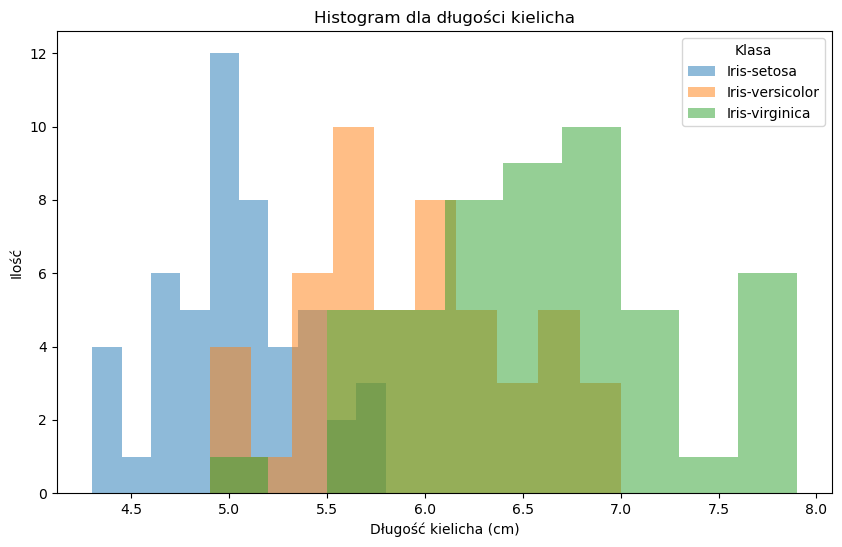

##### Długość kielicha:

- najkrótszy kielich - Iris-setosa
- najdłuższy kielich - Iris virginica

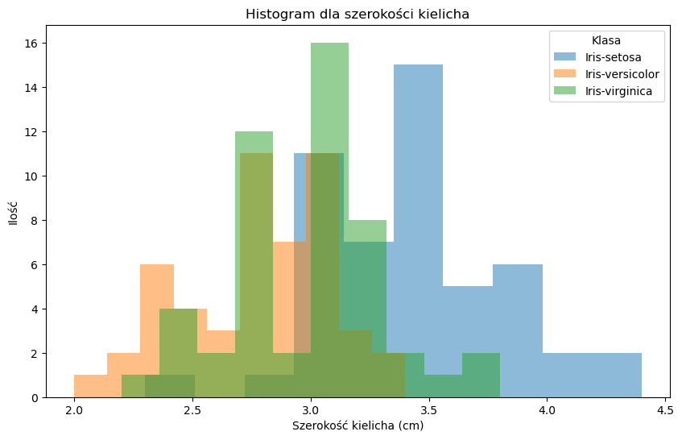

##### Szerokość kielicha:

- najszerszy kielich - Iris-setosa
- Iris virginica i versicolor mają zbliżone wartości
- szerokość kielicha ma podobną wielkość odchylenia standardowego dla wszystkich gatunków, co sugeruje, że może nie być kluczową cechą do ich rozróżnienia.

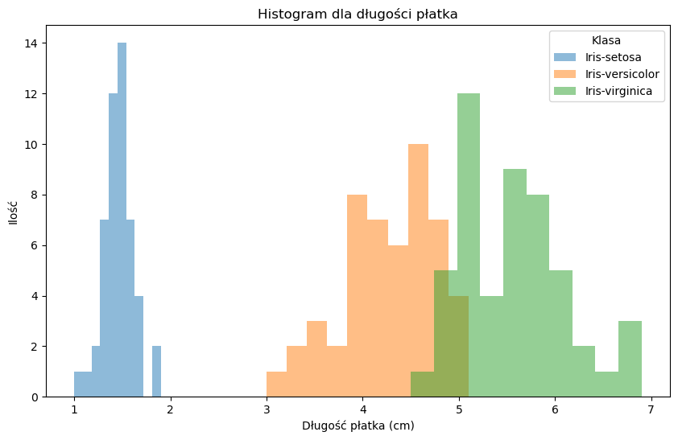

##### Długość płatka:

- Iris setosa ma najkrótsze płatki
- Iris virginica ma najdłuższe płatki

Długość płatka jest silnym wskaźnikiem różnicującym gatunki.

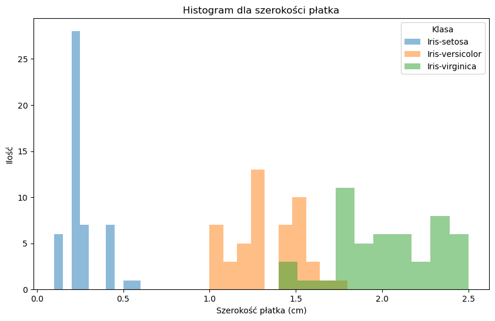

##### Szerokość płatka:

- Iris setosa ma bardzo wąskie płatki
- Iris virginica – najszersze płatki

Różnice są bardzo wyraźne! Szerokość płatka prawdopodobnie będzie najlepszym parametrem do klasyfikacji irysów! Setosa ma wyjątkowo wąskie płatki, co mocno odróżnia ją od innych gatunków.

##### WYKRESY SŁUPKOWE

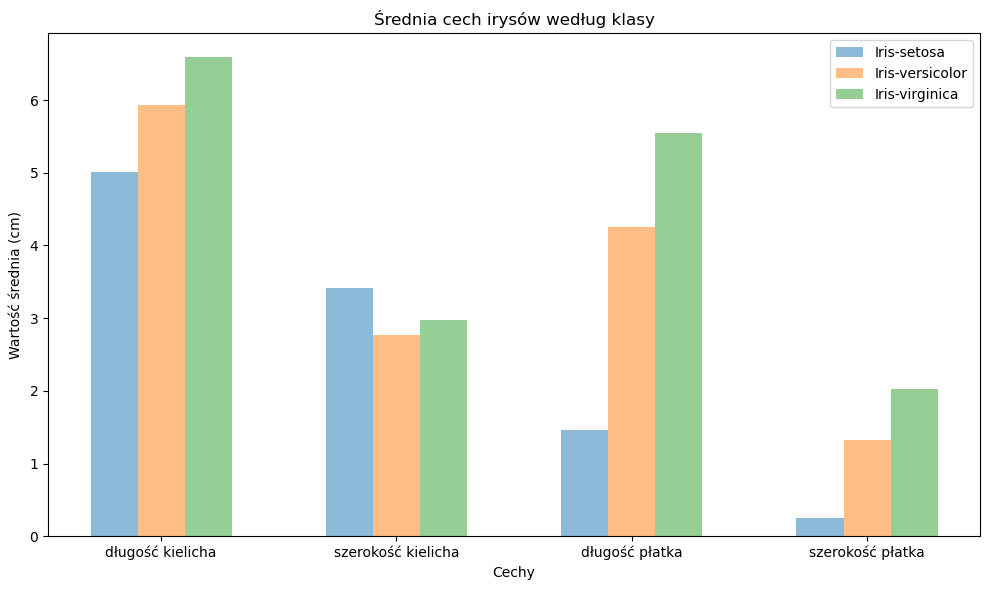

Uwzględniając wartości średnie dla każdej cechy widzimy wyraźnie:

Iris-setosa

ma wyraźnie krótsze i weższe płatki a także krótsze kielichy niż pozostałe klasy. Jest łatwa do odróżnienia od Iris-versicolor i Iris-virginica.

Iris-virginica

Iris-versicolor

zajmuje wartości pośrednie.

### KROK 4 - transformacja danych

**W klasie Iris setosa mamy dwa duplikaty, dla Iris-virginica mamy jeden. Liczba duplikatów nie jest duża, zakładam, że w naturze możliwe jest istnienie identycznych egzemplarzy irysów, stąd decyzja o ich pozostawieniu.**

### KROK 5 - Analiza relacji

#### MACIERZ KORELACJI

|  | długość kielicha | szerokość kielicha | długość płatka | szerokość płatka |
| --- | --- | --- | --- | --- |
| długość kielicha | 1.00 | -0.11 | 0.87 | 0.82 |
| szerokość kielicha | -0.11 | 1.00 | -0.42 | -0.36 |
| długość płatka | 0.87 | -0.42 | 1.00 | 0.96 |
| szerokość płatka | 0.82 | -0.36 | 0.96 | 1.00 |

1. Silna korelacja między długością a szerokością płatka co sugeruje, że dłuższe płatki są jednocześnie szersze.
2. Długość płatka mocno skorelowana z długością kielicha – dłuższy kielich zwykle idzie w parze z dłuższym płatkiem.
3. Szerokość kielicha jest najsłabiej skorelowana z innymi cechami

#### WYKRESY PUNKTOWE

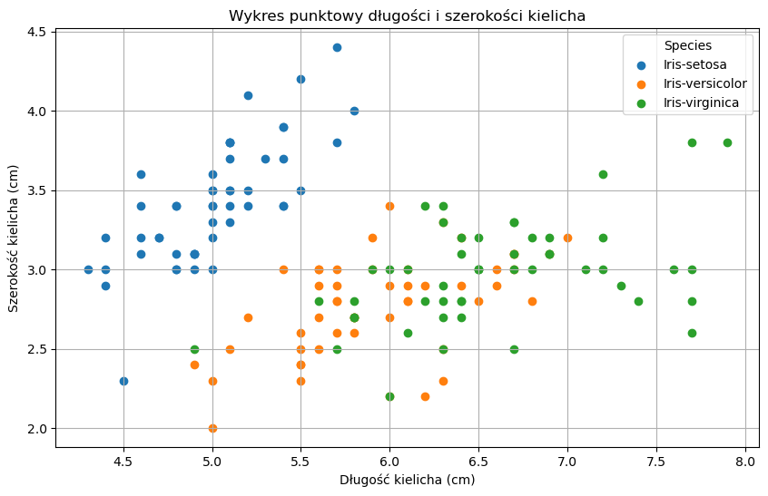

1. Brak wyraźnego podziału między klasami, chociaż Iris-setosa wyróżnia się, ponieważ ma większą szerokość kielicha w porównaniu do innych klas.
2. Punkty dla Iris-versicolor i Iris-virginica znacznie się nakładają, co utrudnia klasyfikację.
3. Długość i szerokość kielicha nie są najlepszymi cechami do klasyfikacji irysów.

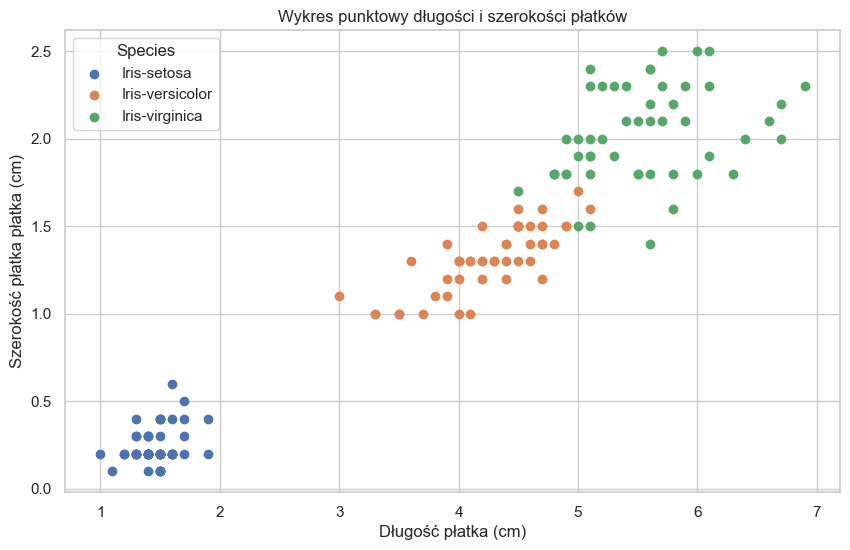

1. Wyraźny podział między klasami, w przeciwieństwie do kielicha, tutaj klasy są dobrze rozdzielone. Iris-setosa jest całkowicie odseparowana od Iris-versicolor i Iris-virginica. Iris-versicolor i Iris-virginica mają niewielką strefę nakładania się, ale większość punktów jest oddzielona.
2. Długość płatka jest kluczową cechą, Iris-setosa ma wyraźnie krótsze płatki, co sprawia, że można ją łatwo sklasyfikować. Iris-virginica ma najdłuższe płatki, a Iris-versicolor zajmuje środkowe wartości.
3. Szerokość płatka dodatkowo wzmacnia podział, a w przypadku Iris-setosa, która ma wyraźnie najwęższe płatki szerokość płatka również pomaga w klasyfikacji.
4. Iris-versicolor i Iris-virginica mają pewne nakładanie się, ale mimo to da się zauważyć tendencję: im dłuższy płatek, tym szerszy.
5. Długość i szerokość płatka to najlepsze cechy do klasyfikacji irysów.
6. Iris-setosa jest całkowicie oddzielona, co sugeruje, że można ją bez problemu rozpoznać.
7. Iris-versicolor i Iris-virginica częściowo się nakładają, ale ogólnie ich rozdzielenie jest znacznie lepsze niż w przypadku kielicha.

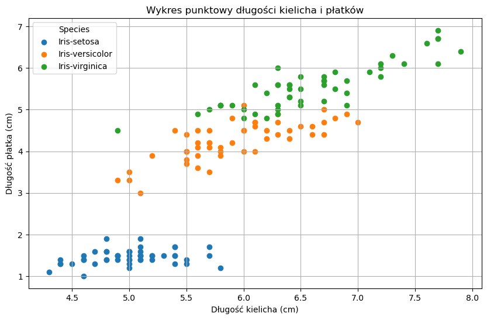

1. Iris-setosa ma wyraźnie krótsze płatki, co dobrze ją odróżnia od innych klas.
2. Iris-versicolor i Iris-virginica wykazują widoczną zależność między długością kielicha a długością płatka – dłuższy kielich zazwyczaj oznacza dłuższy płatek. Jednak klasy nie są tu idealnie oddzielone – Iris-versicolor i Iris-virginica częściowo się pokrywają.

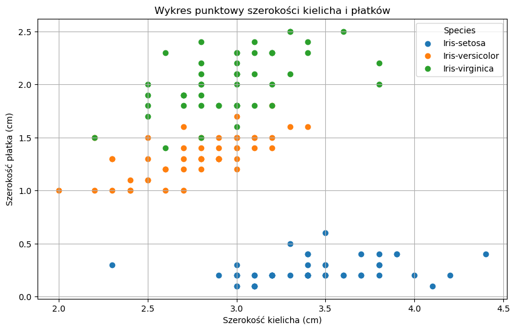

1. Brak silnej zależności między szerokością kielicha a szerokością płatka.
2. Iris-setosa jest najlepiej oddzielona. Posiada najwęższe płatki i stosunkowo szeroki kielich.
3. Iris-versicolor i Iris-virginica nakładają się. Obie klasy mają płatki szerokie na ponad 1 cm, co oznacza, że same szerokości nie wystarczą do ich dokładnego odróżnieniaIris-virginica ma tendencję do posiadania szerszych płatków (1.4 - 2.5 cm), ale występuje częściowe nakładanie się z Iris-versicolor (1.0 - 1.8 cm). Nie ma wyraźnej granicy między tymi dwiema klasami, więc szerokości same w sobie nie są idealnym predyktorem
4. W przeciwieństwie do długości, szerokość kielicha nie wpływa znacząco na szerokość płatka. Punkty na wykresie nie układają się w wyraźny wzór – są bardziej rozproszone.

**Najlepsza para cech do klasyfikacji: Długość płatka vs. szerokość płatka – tutaj klasy są najlepiej rozdzielone.**

**Iris-setosa jest zawsze dobrze odseparowana, niezależnie od pary cech.** **Iris-versicolor i Iris-virginica czasami się nakładają, ale płatki (ich długość i szerokość) są kluczowe do ich odróżnienia.**

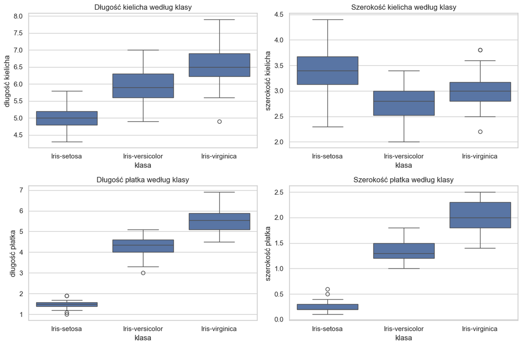

**Widoczne wartości odstające pojawiają się przy analizie każdej z cech Irysów, są jednak nieliczne, nie wpływają więc znacznie na podstawowe statystyki (średnią, odchylenie standardowe). W mojej ocenie nie prowadzą do zniekształcenia wyników i wniosków.**

# PODSUMOWANIE:

#### Iris setosa

jest najłatwiejsza do odróżnienia, jest to gatunek najbardziej jednolity – ma wyraźnie szerszy kielich i bardzo małe, wąskie płatki. Długość i szerokość płatka wyraźnie oddzielają Iris setosa od reszty. Maksymalna długość płatka tylko 1.9 cm, podczas gdy u innych gatunków minimalna wartość to 3.0 cm (versicolor) i 4.5 cm (virginica).

Podobnie szerokość płatka u Iris setosa nigdy nie przekracza 0.6 cm, a u versicolor minimalna to 1.0 cm, a u virginica 1.4 cm. To oznacza, że jeśli mamy irysa z płatkami o szerokości powyżej 2 cm długości, to na pewno NIE jest to Iris setosa!

##### Iris versicolor i Iris virginica

są bardziej podobne do siebie, ale można je rozróżnić na podstawie długości i szerokości płatków. Obydwa gatunki mają taką samą minimalną długość kielicha (4.9 cm), więc trudno je odróżnić tylko na tej podstawie.

##### Iris virginica

Szerokość kielicha ma podobną wielkość odchylenia standardowego dla wszystkich gatunków, co sugeruje, że może nie być kluczową cechą do ich rozróżnienia. Najlepsze cechy do klasyfikacji to szerokość płatka i długość płatka

##### Iris versicolor

leży pośrodku i ma największe nakładanie się wartości z virginicą. Może być trudniejsza do odróżnienia, ale różnice w szerokości i długości płatka mogą pomóc.

- najlepsza cecha do klasyfikacji: szerokość płatka
- najlepiej odróżniający się gatunek: Iris setosa
- najbardziej zmienna grupa: Iris virginica